# homework01

> **Student Names and IDs**:
> - Divya Chowbey, 0710368
> - Feroze Mohideen, 0707410
> - Caroline Wang, 0707659

#### Problem 1.1

> Spell out the system $$A \mathbf{c} = \mathbf{a}$$ for this special case.

> Consider: $$ A = \left[\begin{array}{cc} 1 & x_{0} \end{array}\right] \;\text{,}\;\;\; \mathbf{c} = \left[\begin{array}{c} c_{0}\\ c_{1} \end{array}\right] \text{, and}\;\;\; \mathbf{a} = \left[\begin{array}{c} y_{0} \end{array}\right] $$

> Rearranging: $$ c_0 +c_1 x_0 = y_0$$

#### Problem 1.2

> Give expressions for two different possible solutions $\mathbf{c}$ to this equation in terms of $x_0$ and $y_0$.

> Possible solutions include: $$ \mathbf{c} = \left[\begin{array}{c} y_0\\ 0 \end{array}\right] \;\;\;\text{and}\;\;\; \mathbf{c} = \left[\begin{array}{c} y_0-x_0\\ 1 \end{array}\right]$$

#### Problem 1.3

> Write and run Python code to draw, in a single plot, the two lines corresponding to the two solutions you gave when $$(x_0, y_0) = (2, 1).$$

```python
import numpy as np
import matplotlib.pyplot as plt

def show(x, y, cList = []):
    plt.ion()
    plt.plot(x, y, marker='.', markersize=12, ls='')
    npt = 100
    xrange = [x - 1, x + 1] if x.size == 1 else [np.amin(x), np.amax(x)]
    xFine = np.linspace(xrange[0], xrange[1], npt)
    for c in cList:
        nc = c.size
        ycFine = np.zeros(xFine.shape)
        xPow = np.ones(xFine.shape)
        for i in range(nc):
            ycFine += c.item(i) * xPow
            xPow *= xFine
        plt.plot(xFine, ycFine, label = 'degree ' + str(nc-1))
    plt.xlabel('x')
    plt.ylabel('y')
    plt.legend()
    plt.show()

# Usage example
p = [2, 1]
show(np.array(p[0]), np.array(p[1]), [np.array([1, 0]), np.array([-1, 1])])
```

#### Problem 2.1

> Derive this last equation from the system $$A\mathbf{c} = \mathbf{a}$$ spelled out for this special case.

> Consider: $ A = \left[\begin{array}{cc} 1 & x_0\\ 1 & x_{1} \end{array}\right] \text{,}\;\;\; \mathbf{c} = \left[\begin{array}{c} c_{0}\\ c_{1} \end{array}\right] \; \text{, and}\;\;\; \mathbf{a} = \left[\begin{array}{c} y_{0} \\ y_{1}\end{array}\right] $

> Substituting: $$\left[\begin{array}{cc} 1 & x_0\\ 1 & x_{1} \end{array}\right] \left[\begin{array}{c} c_{0}\\ c_{1} \end{array}\right] = \left[\begin{array}{c} y_{0} \\ y_{1}\end{array}\right]$$

> Applying Gaussian Elimination: $$ \left[\begin{array}{cc|c} 1 & x_0 & y_{0}\\ 1 & x_{1} & y_{1}\end{array}\right]$$

> $$ \left[\begin{array}{cc|c} 1 & x_0 & y_{0}\\ 0 & x_{1}-x_{0} & y_{1}-y_{0} \end{array}\right]$$

> $$ \left[\begin{array}{cc|c} 1 & 0 & y_{0} - \frac{x_{0}}{x_{1}-x_{0}} (y_{1}-y_{0}) \\ 0 & x_{1}-x_{0} & y_{1}-y_{0} \end{array}\right]$$

> $$ \left[\begin{array}{cc|c} 1 & 0 & y_{0} - \frac{x_{0}}{x_{1}-x_{0}} (y_{1}-y_{0}) \\ 0 & 1 & \frac{y_{1}-y_{0}}{x_{1}-x_{0}} \end{array}\right]$$

> Therefore, $$ c_0 = y_{0} - \frac{x_{0}}{x_{1}-x_{0}} (y_{1}-y_{0}) \;\;\; \text{and}\;\;\; c_1= \frac{y_{1}-y_{0}}{x_{1}-x_{0}} $$

> Substituting $c_0 \;\text{and}\; c_1 \;:$ $$ c_0 + c_1 x = y $$

> $$ y_{0} - \left( \frac{x_{0}}{x_{1}-x_{0}}\right) \left(y_{1}-y_{0}\right) + \left( \frac{y_{1}-y_{0}}{x_{1}-x_{0}} \right) x = y $$

> $$ (x- x_0)\left( \frac{y_{1}-y_{0}}{x_{1}-x_{0}} \right) = y - y_0 $$

#### Problem 3.1

> Write the matrix $A^T A$ and vector $A^T \mathbf{a}$ in terms of $N, X, Y, S, P$ for the special case $k=1$.

> Consider: $A = \left[\begin{array}{cc} 1 & x_0\\ 1 & x_{1} \\ 1 & x_{2} \end{array}\right] $ and $\mathbf{a} = \left[\begin{array}{c} y_{0} \\ y_{1} \\ y_{2} \end{array}\right] $, where $A^T = \left[\begin{array}{ccc} 1 & 1 & 1 \\ x_0 & x_{1} & x_{2} \end{array}\right] $

> (i) $$ A^T A = \left[\begin{array}{cc} 1 & x_0\\ 1 & x_{1} \\ 1 & x_{2} \end{array}\right]\left[\begin{array}{ccc} 1 & 1 & 1 \\ x_0 & x_{1} & x_{2} \end{array}\right]$$

$$ = \left[\begin{array}{cc} 3 & x_0 + x_1+x_2 \\x_0 + x_1+x_2 & x_0^2 + x_1^2+x_2^2 \end{array}\right]$$

$$ = \left[\begin{array}{cc} N & X \\X & S \end{array}\right]$$

> (ii) $$ A^T\mathbf{a} = \left[\begin{array}{ccc} 1 & 1 & 1 \\ x_0 & x_{1} & x_{2} \end{array}\right] \left[\begin{array}{c} y_{0} \\ y_{1} \\ y_{2} \end{array}\right]$$

$$ = \left[\begin{array}{ccc}y_{0} +y_{1}+ y_{2} \\ x_0y_{0} +x_1y_{1}+ x_2y_{2}\end{array}\right]$$

$$ = \left[\begin{array}{c} Y\\ P \end{array}\right] $$

#### Problem 3.2

> Find expressions for $c_0$ and $c_1$ in terms of $N, X, Y, S, P$ by solving the normal equations. Recall that $$\left[\begin{array}{cc}a & b\\c & d \end{array}\right]^{-1} \;=\; \frac{1}{ad-bc}\ \left[\begin{array}{rr}d & -b\\-c & a \end{array}\right]$$

> $$ A^T A \mathbf{c} = A^T \mathbf{a} $$ $$ \left[\begin{array}{cc} N & X \\X & S \end{array}\right] \left[\begin{array}{c} c_0\\ c_1 \end{array}\right] = \left[\begin{array}{c} Y\\ P \end{array}\right]$$ $$ \left[\begin{array}{cc} N & X \\X & S \end{array}\right]^{-1} \left[\begin{array}{cc} N & X \\X & S \end{array}\right] \left[\begin{array}{c} c_0\\ c_1 \end{array}\right] = \left[\begin{array}{cc} N & X \\X & S \end{array}\right]^{-1}\left[\begin{array}{c} Y\\ P \end{array}\right]$$

> Where: $$ \left[\begin{array}{cc} N & X \\X & S \end{array}\right]^{-1} = \frac{1}{NS-X^2}\ \left[\begin{array}{rr}S & -X\\-X & N \end{array}\right]$$

> Therefore: $$ \left[\begin{array}{c} c_0\\ c_1 \end{array}\right] = \frac{1}{NS-X^2}\ \left[\begin{array}{rr}S & -X\\-X & N \end{array}\right]\left[\begin{array}{c} Y\\ P \end{array}\right]$$

> $$ \left[\begin{array}{c} c_0\\ c_1 \end{array}\right] = \frac{1}{NS-X^2}\ \left[\begin{array}{r}SY-PX\\-XY +NP \end{array}\right]$$

#### Problem 3.3

> Use the function `show` given earlier to display the three points $(0, -1), (1, 1), (3, 0)$ and the line fit to them with the formulas you just found for $c_0$ and $c_1$.

```
c0:  -0.286
c1:  0.214
```

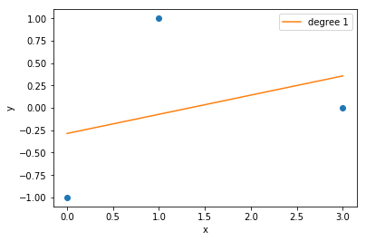

```python
x = [0, 1, 3]
y = [-1, 1, 0]

N = len(y)
S = sum([x[i]**2 for i in range(len(x))])
X = sum(x)
Y = sum(y)
P = sum([x[i]*y[i] for i in range(len(x))])

c_0 = (1/(N*S - X**2))*(S*Y- P*X)
c_1 = (1/(N*S - X**2))*(-X*Y+N*P)

print("c0: ", "{0:.3f}".format(c_0))
print("c1: ", "{0:.3f}".format(c_1))



show(np.array(x), np.array(y), [np.array([c_0, c_1])])
```